# Análise da Paisagem

Aula 19 - Unidades de Paisagem: Delimitação e Caracterização  
Curso de Geografia

Luiz Diego Vidal Santos

## Visão Geral da Aula

### Tópicos

- 1 O que são unidades de paisagem
- 2 Critérios de delimitação
- 3 Métodos de delimitação
- 4 Caracterização e ficha descritiva
- 5 Integração de evidências
- 6 Oficina: delimitação na área de estudo

**Objetivo da Aula**

Compreender o conceito de **unidades de paisagem**, aplicar **critérios de delimitação** e elaborar **fichas descritivas** integrando evidências cartográficas, espectrais e métricas para a área de estudo - etapa central do dossiê.

# 1 - O QUE SÃO UNIDADES DE PAISAGEM

## Conceito e finalidade

### Definição

**Unidades de paisagem** são porções do território delimitadas com base na **homogeneidade relativa** de seus componentes (relevo, cobertura, uso, processos) e nas **relações funcionais** que os integram.

### Outros nomes

- Unidades geoambientais (Ab’Sáber)
- Geocomplexos (Bertrand)
- Geofácies / Geótopos (hierarquia escalar)
- Unidades de terra (land units)
- Paisagens elementares (escola soviética)

### Finalidade

1. **Síntese espacial** - organizar a diversidade da paisagem em unidades manejáveis
2. **Diagnóstico** - cada unidade permite avaliação específica de potencialidades e limitações
3. **Planejamento** - base para zoneamentos e diretrizes diferenciadas
4. **Comunicação** - facilitar a leitura do território por diferentes atores

**Unidade de paisagem ≠ classe de uso**

| Aspecto | Classe de uso | Unidade de paisagem |
| --- | --- | --- |
| **Base** | Cobertura/uso | Integração de componentes |
| **Critério** | Espectral/visual | Funcional/estrutural |
| **Limite** | Pixel/polígono | Gradiente/transição |
| **Conteúdo** | Uma variável | Múltiplas variáveis |
| **Produto** | Mapa temático | Mapa-síntese |

### Exemplo

Uma **“Planície fluvial com pastagem degradada e fragmentos de mata ciliar”** é uma unidade de paisagem que integra:

- Relevo (planície)
- Geomorfologia (fluvial)
- Uso (pastagem)
- Estado (degradada)
- Vegetação remanescente (mata ciliar)
- Processo (erosão fluvial, assoreamento)

> A unidade não é apenas “pastagem” - é a **articulação** de componentes em um espaço funcional.

# 2 - CRITÉRIOS DE DELIMITAÇÃO

## Que variáveis usar?

### Critérios de 1ª ordem (estruturais)

| Critério | Variável | Fonte |
| --- | --- | --- |
| **Relevo** | Classes de declividade, formas, altitude | MDE (TOPODATA, SRTM) |
| **Geomorfologia** | Compartimentos, modelados | Mapa geomorfológico (IBGE, CPRM) |
| **Geologia/solos** | Litologia, tipo de solo | CPRM, EMBRAPA |
| **Hidrografia** | Rede de drenagem, bacias | ANA, bases topográficas |

### Critérios de 2ª ordem (cobertura/uso)

| Critério | Variável | Fonte |
| --- | --- | --- |
| **Cobertura vegetal** | Tipo, estado, proporção | MapBiomas, Sentinel-2 |
| **Uso da terra** | Atividade dominante | Interpretação visual, IBGE |
| **Padrão espacial** | Fragmentação, conectividade | Métricas (Aulas 17-18) |
| **Dinâmica** | Tendência de mudança | Série temporal (Aulas 15-16) |

### Critérios de 3ª ordem (processos/pressões)

| Critério | Variável | Fonte |
| --- | --- | --- |
| **Erosão** | Cicatrizes, voçorocas | Imagem, campo |
| **Urbanização** | Expansão, impermeabilização | Imagem, dados censitários |
| **Disponibilidade hídrica** | Perenidade, açudes | ANA, campo |
| **Pressão antrópica** | Intensidade de uso | Interpretação integrada |

**Princípio-chave**

> *“A delimitação de unidades de paisagem é um ato de SÍNTESE, não de soma.”*

Não se trata de sobrepor todos os mapas. Trata-se de identificar **padrões recorrentes** - combinações de relevo + cobertura + uso + processo que se repetem e definem porções funcionalmente distintas do território.

# 3 - MÉTODOS DE DELIMITAÇÃO

## Abordagens práticas

### Método 1: Sobreposição ponderada (overlay)

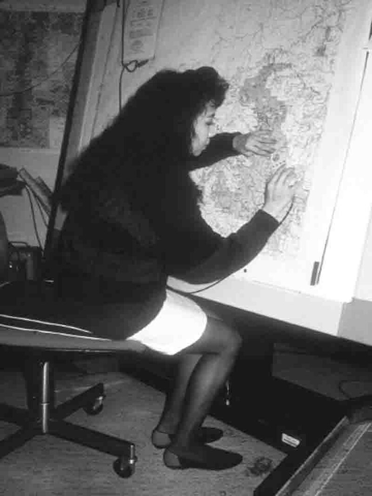

Sobreposição de camadas temáticas em SIG

1. Reunir mapas temáticos (relevo, uso, vegetação, processos)
2. Sobrepor em GIS (QGIS)
3. Identificar **zonas de convergência** - onde vários fatores mudam simultaneamente
4. Delimitar limites com base nos gradientes

**Vantagem:** reproduzível, particiável **Limitação:** depende da qualidade e resolução dos dados

### Método 2: Interpretação integrada (expert)

1. Visualizar composições de imagem + MDE + mapas
2. Identificar **padrões visuais** - textura, tonalidade, forma, arranjo
3. Delimitar unidades por **julgamento do especialista**
4. Validar com dados e/ou campo

**Vantagem:** capta nuances que algoritmos perdem **Limitação:** subjetividade, difícil replicar

### Método 3: Combinação (recomendado)

1. Usar overlay como **base inicial**
2. Ajustar por **interpretação integrada**
3. Validar com **métricas e campo**

### Hierarquia escalar (Bertrand adaptado)

| Nível | Escala | Critério dominante | Exemplo |
| --- | --- | --- | --- |
| **1 - Domínio** | Regional | Clima + bioma | Semiárido / Caatinga |
| **2 - Região** | Sub-regional | Geomorfologia | Depressão sertaneja |
| **3 - Geossistema** | Paisagem | Relevo + cobertura | Pediplano com caatinga |
| **4 - Geofácies** | Local | Uso + vegetação | Pastagem em glacis |
| **5 - Geótopo** | Sítio | Microprocesso | Voçoroca em vertente |

**Para a disciplina:** trabalharemos no nível **3-4** (geossistema/geofácies), que corresponde à escala de análise da área de estudo.

# 4 - FICHA DESCRITIVA

## Modelo de caracterização

### Ficha descritiva da Unidade de Paisagem

| Campo | Conteúdo |
| --- | --- |
| **Nome/código** | UP-1: Planície fluvial com pastagem degradada |
| **Localização** | Porção central da área, ao longo do rio principal |
| **Área** | ~320 ha (6,4% da área total) |
| **Relevo** | Planície aluvial, declividade < 3%, altitude 250-260 m |
| **Cobertura** | Pastagem degradada (70%), mata ciliar (15%), solo exposto (15%) |
| **Uso** | Pecuária extensiva de baixa produtividade |
| **Processos** | Erosão marginal, assoreamento, compactação do solo |
| **Pressões** | Sobrepastejo, supressão de mata ciliar, eventos de cheia |
| **Vulnerabilidade** | Alta - solo exposto em margem, APP desprotegida |
| **Potencialidade** | Restauração de APP, pasto com manejo, corredor ecológico |
| **NDVI médio** | 0,22 (pastagem degradada) |
| **Evidências** | Mapa uso/cobertura, NDVI, imagem Sentinel-2, MDE |
| **Conexão** | Conecta UP-2 (encosta) e UP-4 (reservatório) |

## Exemplo: mapa de unidades (esquemático)

### Unidades delimitadas (exemplo)

| Código | Nome | Área (%) |
| --- | --- | --- |
| UP-1 | Planície fluvial com pastagem degradada | 6,4% |
| UP-2 | Encosta com caatinga remanescente | 12,0% |
| UP-3 | Pediplano com pastagem extensiva | 48,0% |
| UP-4 | Entorno do reservatório (açude) | 3,0% |
| UP-5 | Topo de serra com caatinga preservada | 8,0% |
| UP-6 | Agricultura irrigada (pivôs) | 12,0% |
| UP-7 | Núcleo urbano e periurbano | 4,6% |
| UP-8 | Áreas degradadas (solo exposto + erosão) | 6,0% |

**Critérios de qualidade do mapa**

- ✅ Unidades mutuamente exclusivas (sem sobreposição)
- ✅ Cobertura total (toda a área classificada)
- ✅ Nome descritivo (relevo + cobertura/uso + estado)
- ✅ Legenda com cores distintas
- ✅ Cada unidade com ficha descritiva
- ✅ Limites justificados (que variável muda?)

### Quantas unidades?

- **Muito poucas** (2-3) → perda de informação
- **Muitas** (> 10) → dificulta síntese e comunicação
- **Ideal:** 5-8 unidades para uma área de estudo local

> O número depende da **heterogeneidade** da paisagem e da **escala** de análise.

# 5 - OFICINA PRÁTICA

## Atividade: delimitar unidades na área de estudo

### Etapas (50 min)

1. **Preparar camadas** (10 min)
   - Abrir no QGIS: MDE, mapa de uso/cobertura, NDVI, imagem Sentinel-2
   - Verificar dados das aulas anteriores
2. **Identificar padrões** (10 min)
   - Com interpretação visual integrada
   - Anotar combinações recorrentes (relevo × uso × cobertura)
3. **Delimitar unidades** (15 min)
   - Criar camada vetorial (polígono)
   - Traçar limites entre unidades (usar gradientes)
   - Nomear cada unidade
4. **Preencher fichas** (10 min)
   - Uma ficha por unidade (modelo fornecido)
   - Incluir evidências (métricas, NDVI, classe MapBiomas)
5. **Revisão** (5 min)
   - Cobertura total? Sobreposição? Nomes descritivos?

**Entrega**

- Mapa de unidades de paisagem (PNG ou PDF)
- Fichas descritivas (1 por unidade)
- Mínimo: **4 unidades**; ideal: **5-8 unidades**

**Prazo:** até Aula 20 (mesma semana)

> Este produto será a peça-chave do dossiê - o **mapa-síntese** que organiza toda a análise.

## Síntese da Aula 19

**O que vimos hoje**

1. **Unidades de paisagem** - conceito: porções homogêneas e funcionalmente integradas
2. **Critérios** - 3 ordens: estruturais (relevo/solo), cobertura/uso, processos/pressões
3. **Métodos** - overlay, interpretação integrada, combinação
4. **Hierarquia escalar** - domínio → região → geossistema → geofácies → geótopo
5. **Ficha descritiva** - modelo com 13 campos (nome, relevo, cobertura, processos, vulnerabilidade…)
6. **Oficina** - delimitação e caracterização na área de estudo

Obrigado!

Luiz Diego Vidal Santos

Universidade Estadual de Feira de Santana (UEFS)

Análise da Paisagem - Aula 19